# R Notebook

```r
library(tidyverse)
library(CodeClanData)

revenue_breakdown <- qb_revenue_breakdown
monthly_sales <- qb_monthly_sales
competitors <- qb_competitors
device_data <- qb_device_data
```

```r
col_scheme <- c("#E89FE9", "#50434F", "#B6A7B5", "#F9A472", "#BD7040")
```

Take the data in the dataset qb_revenue_breakdown and make a stacked bar chart showing the sources of revenue across the two years in the dataset.

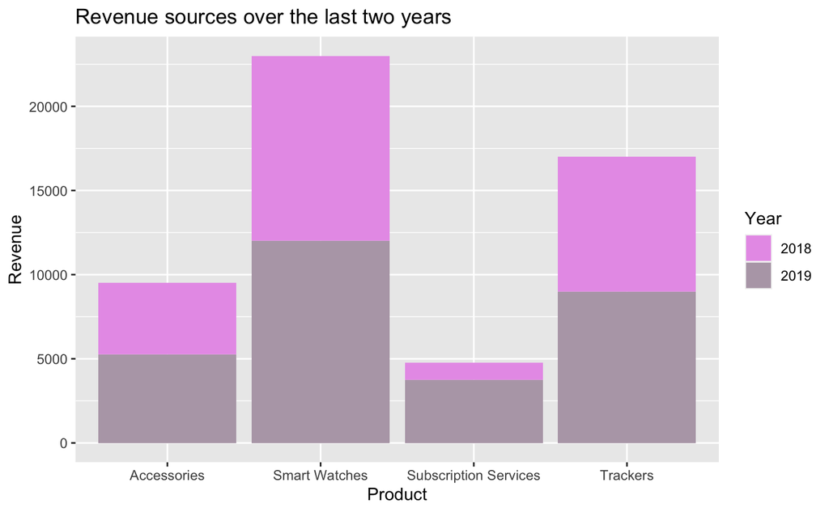

```r
ggplot(revenue_breakdown) +
  aes(x = Product, y = Revenue, fill = Year) +
  geom_col(position = "stack") +
  labs(title = "Revenue sources over the last two years", size = 12) +
  scale_fill_manual(
    values = c(
      "2018" = "#E89FE9",
      "2019" = "#B6A7B5"
    )
  )
```

Make a line chart showing monthly sales of the “flagship product” - the KwikBit Unit1 - over the last year. This data is inside qb_monthly_sales, but you will need to use subset.

```r
sales_subset <- monthly_sales %>%
  filter(Cashflow == "Kwikbit Unit 1 Sales")
```

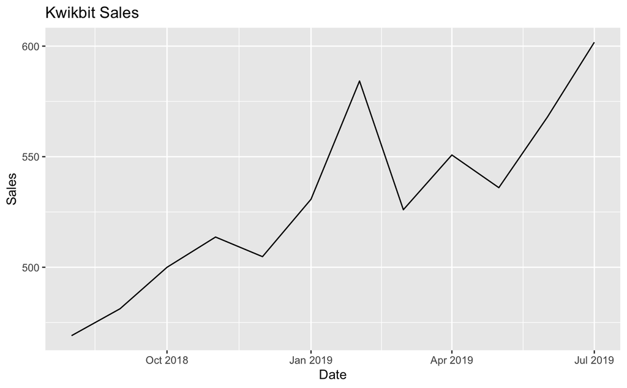

```r
ggplot(sales_subset) +
  aes(x = Date, y = Amount) +
  geom_line() +
  labs(title = "Kwikbit Sales", size = 12) +
  ylab("Sales")
```

Make a line chart showing monthly revenue and costs over the last year. This data is also in qb_monthly_sales.

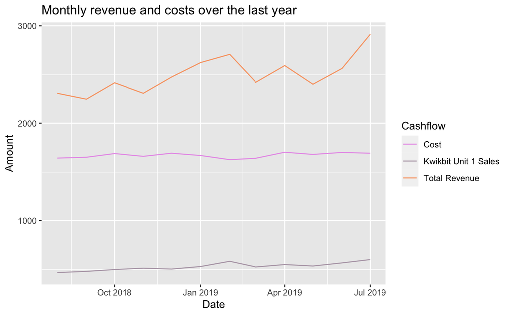

```r
ggplot(monthly_sales) +
  aes(x = Date, y = Amount, colour = Cashflow) +
  geom_line() +
  labs(title = "Monthly revenue and costs over the last year", size = 12) +
  scale_colour_manual(
    values = c(
      "Cost" = "#E89FE9",
      "Kwikbit Unit 1 Sales" = "#B6A7B5",
      "Total Revenue" = "#F9A472"
    )
  )
```

Show annual sales of personal fitness trackers over the last 5 years broken down by company as a ribbon plot (use geom_area). This data is in qb_competitors.

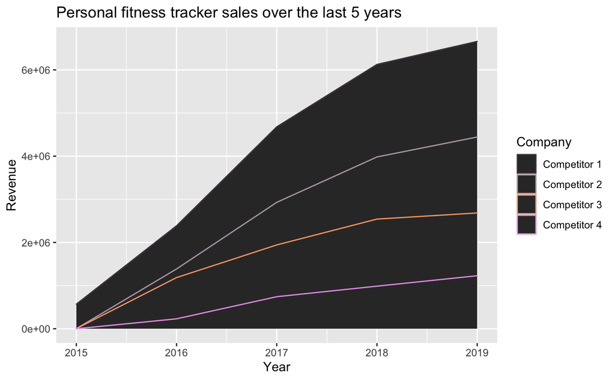

```r
ggplot(competitors) +
  aes(x = Year, y = Revenue, colour = Company) +
  geom_area() +
  labs(title = "Personal fitness tracker sales over the last 5 years", size = 12) +
  scale_colour_manual(
    values = c(
      "Competitor 1" = "#50434F",
      "Competitor 2" = "#B6A7B5",
      "Competitor 3" = "#F9A472",
      "Competitor 4" = "#E89FE9"
    )
  )
```

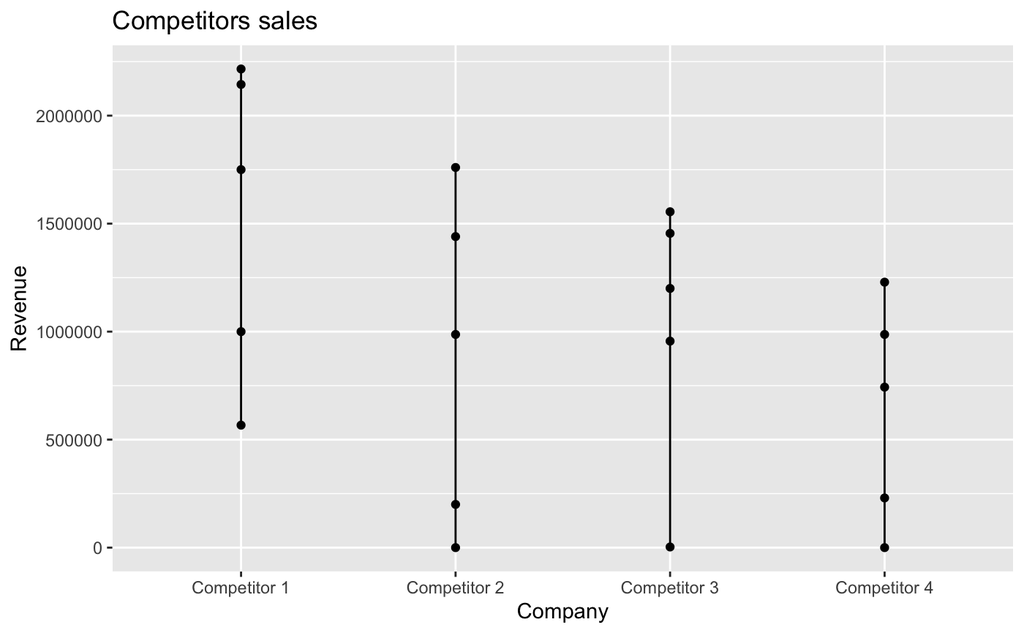

```r
ggplot(competitors) +
  aes(x = Company, y = Revenue) +
  geom_line() +
  geom_point() +
  labs(title = "Competitors sales", size = 12)
```

Now the company wants to compare the number of steps that their device counts vs. their competitors. Make a line graph of the number of steps throughout time, and use faceting to compare between individuals and people. Data is in qb_device_data.

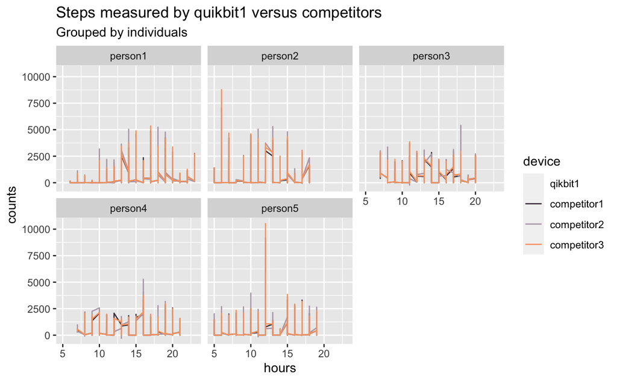

```r
ggplot(device_data) +
  aes(x = hours, y = counts, colour = device) +
  geom_line() +
  facet_wrap(~ id) +
  labs(title = "Steps measured by quikbit1 versus competitors",
       subtitle = "Grouped by individuals") +
  scale_colour_manual(
    values = c(
      "quikbit1" = "#E89FE9",
      "competitor1" = "#50434F",
      "competitor2" = "#B6A7B5",
      "competitor3" = "#F9A472"
    )
  )
```